# Homework 4

   First we sort the date from highest to lowest reported age using the order function.

```r
ordered<- fin[order(fin$Age, decreasing = TRUE), ]
```

Then we find the Age median from fin dataset. As we can see, the median is 24 (in the column 67 since is exactly the middle of 133).

```r
median(fin$Age)
```

```
[1] 24
```

Since I have the ordered dataframe (from the highest to lowest Age), I use it to create two other dataframes, one for the younger Age group “orderedyoung”, and one for the older Age group “orderedold”.

```r
orderedyoung <- ordered[-c(1:66), ]
orderedold <- ordered[-c(68:133), ]
```

orderedold%>% ggplot(aes(x= Age, y= summm)) + geom_point()

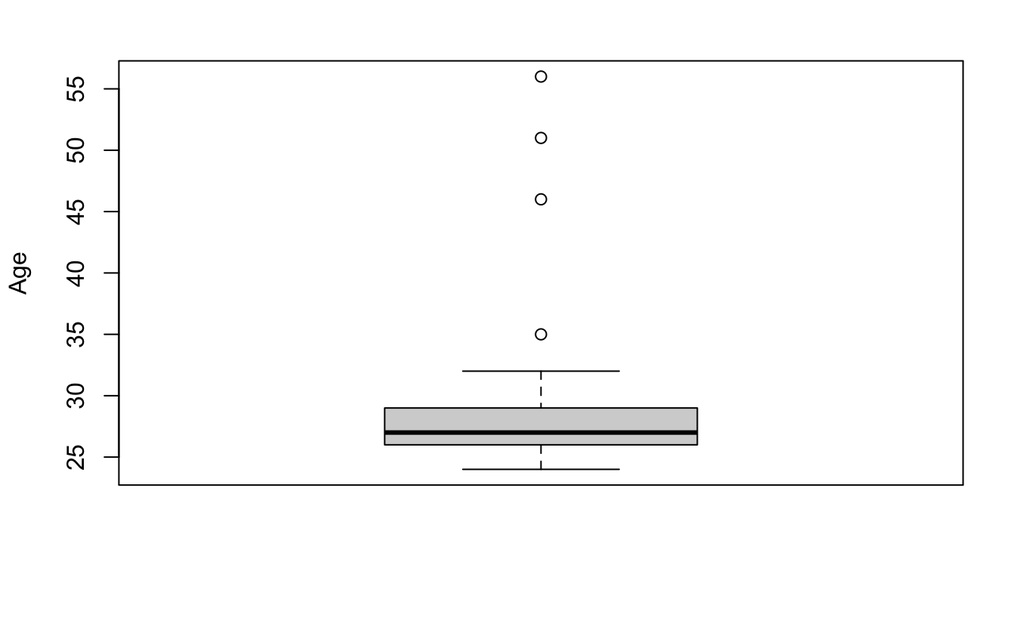

```r
boxplot(orderedold$Age,
  ylab = "Age")
```

```r
boxplot.stats(orderedold$Age)$out
```

```
[1] 56 51 46 35
```

```r
out <- boxplot.stats(orderedold$Age)$out
out_ind <- which(orderedold$Age %in% c(out))
out_ind
```

```
[1] 1 2 3 4
```

```r
oo <- orderedold[-c(1,2,3,4), ]

oy <- orderedyoung[-c(67), ]
```

I use the ggplot function to create a graph that indicates the Age of the participants in the x axes, and the number of correct guesses (summm) in the y axes. As we can see, while the Age column now indicates only the oldest people, the majority is still under 30 – closer to the median. From the age 24 until 30s, the amount of correct responses seems to decline. We use the median and the mean code in order to see if there is a difference with them. Median indicates that there is no difference among the data as the reported correct outcome. However, if we look at the mean of the two, the younger group tends to report more correct answers on average than the older group. This difference is small though (4.62-3.92)

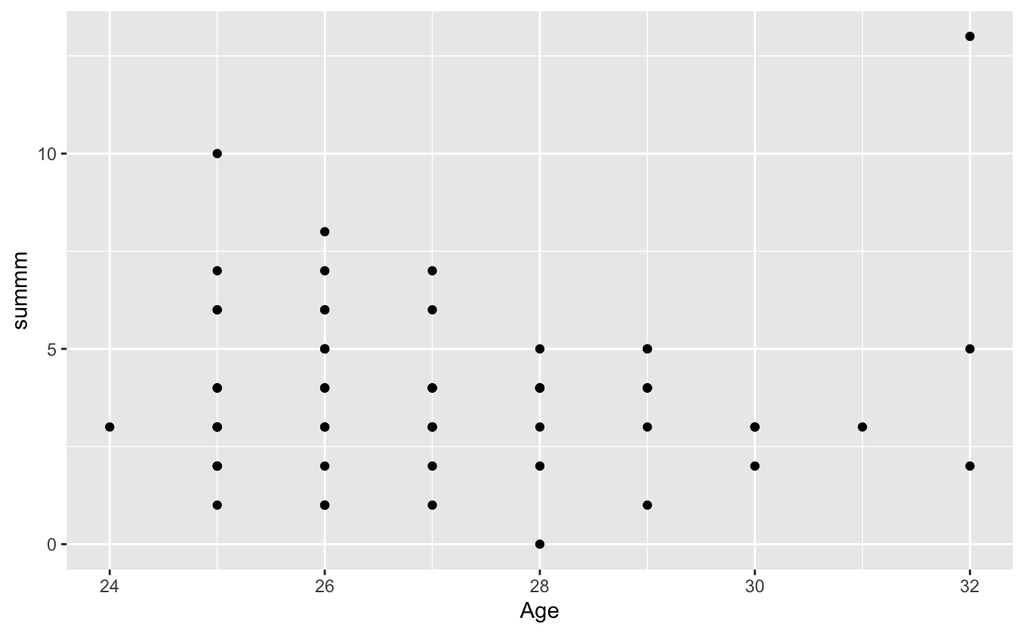

```r
oo%>% ggplot(aes(x= Age, y= summm)) + geom_point()
```

```r
median(oo$summm)
```

```
[1] 4
```

```r
mean(oo$summm)
```

```
[1] 3.920635
```

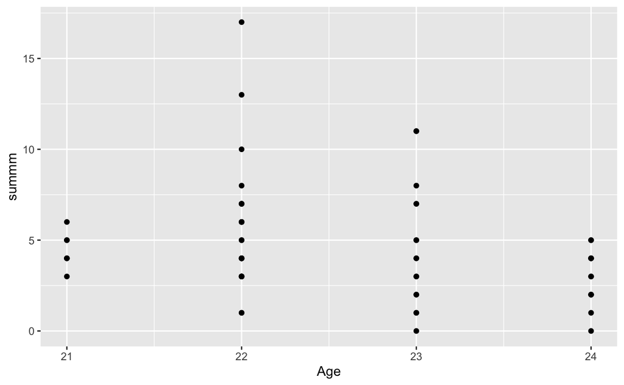

```r
oy%>% ggplot(aes(x= Age, y= summm)) + geom_point()
```

```r
median(oy$summm)
```

```
[1] 4
```

```r
mean(oy$summm)
```

```
[1] 4.621212
```